# Lending Club Loans' Default Prediction--By Clara Liu

# 6. Modeling

Metric: AUC, Confusion Matrix

I use AUC because of the unbalanced distribution of target variable. Confusion Matrix is used to help to balance the relationship of False Positive and False Negative. We definitely want to prevent default in this case. Usually the loss of a default is much larger than the revenue generated by a loan.

```python
import itertools
sns.set('talk', 'whitegrid', 'dark', font_scale=1, font='Ricty',rc={"lines.linewidth": 2, 'grid.linestyle': '--'})
def plotAUC(truth, pred, lab):
    fpr, tpr, _ = metrics.roc_curve(truth,pred)
    roc_auc = metrics.auc(fpr, tpr)
    lw = 2
    c = (np.random.rand(), np.random.rand(), np.random.rand())
    plt.plot(fpr, tpr, color= c,lw=lw, label= lab +'(AUC = %0.2f)' % roc_auc)
    plt.plot([0, 1], [0, 1], color='navy', lw=lw, linestyle='--')
    plt.xlim([0.0, 1.0])
    plt.ylim([0.0, 1.0])
    plt.xlabel('False Positive Rate')
    plt.ylabel('True Positive Rate')
    plt.title('ROC curve') #Receiver Operating Characteristic
    plt.legend(loc="lower right")
def plot_confusion_matrix(model, normalize=False): # This function prints and plots the confusion matrix.
    cm = confusion_matrix(y_test, model, labels=[0, 1])
    classes=["Non Default", "Default"]
    cmap = plt.cm.Blues
    title = "Confusion Matrix"
    if normalize:
        cm = cm.astype('float') / cm.sum(axis=1)[:, np.newaxis]
        cm = np.around(cm, decimals=3)
    plt.imshow(cm, interpolation='nearest', cmap=cmap)
    plt.title(title)
    plt.colorbar()
    tick_marks = np.arange(len(classes))
    plt.xticks(tick_marks, classes, rotation=45)
    plt.yticks(tick_marks, classes)
    thresh = cm.max() / 2.
    for i, j in itertools.product(range(cm.shape[0]), range(cm.shape[1])):
        plt.text(j, i, cm[i, j],
                 horizontalalignment="center",
                 color="white" if cm[i, j] > thresh else "black")
    plt.tight_layout()
    plt.ylabel('True label')
    plt.xlabel('Predicted label')
```

```python
# Prepare for Cross Validation
kfold = 5
random_state = 0
```

# 6.1 Logistic Regression

Train LR model. I set class_weight to 0:1,1:2.3 because false negative rate is not too high and auc is acceptable.

```python
y_train.value_counts()
```

```
0    75999
1    26777
Name: default, dtype: int64
```

```python
lr = LogisticRegression(random_state=0, class_weight={0:1,1:2.3})
c=[0.0000001, 0.000001, 0.00001, 0.0001, 0.001, 0.01, 0.1, 1, 10, 100]
param_grid = dict(C=c)
grid = GridSearchCV(lr, param_grid,cv=kfold, scoring='roc_auc')
grid.fit(X_train,y_train)

lr_best=grid.best_estimator_
lr_best.fit(X_train,y_train)

#training data performance
predicted_lr = lr_best.predict(X_train)
Predict_lr_proba = lr_best.predict_proba(X_train)[:,1]
print(confusion_matrix(y_train, predicted_lr))
print(metrics.roc_auc_score(y_train, Predict_lr_proba))

#testing data performance
predicted_lr_test = lr_best.predict(X_test)
Predict_lr_proba = lr_best.predict_proba(X_test)[:,1]
print(confusion_matrix(y_test, predicted_lr_test))
print(metrics.roc_auc_score(y_test, Predict_lr_proba))
```

```
[[57165 18834]
 [12311 14466]]
0.71341016101
[[19051  6295]
 [ 4018  4895]]
0.713946220923
```

```python
lr_best
```

```
LogisticRegression(C=0.1, class_weight={0: 1, 1: 2.3}, dual=False,
          fit_intercept=True, intercept_scaling=1, max_iter=100,
          multi_class='ovr', n_jobs=1, penalty='l2', random_state=0,
          solver='liblinear', tol=0.0001, verbose=0, warm_start=False)
```

Visualization

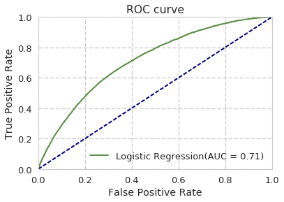

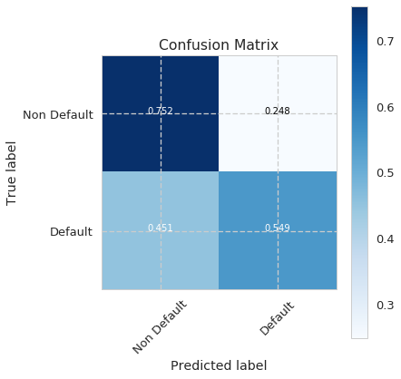

```python
plotAUC(y_test,Predict_lr_proba,'Logistic Regression')
plt.show()
plt.figure(figsize=(6,6))
plot_confusion_matrix(predicted_lr_test, normalize=True)
plt.show()
```

# 6.2 Random Forest

I will use Randomized Search to tune hyperparameters. The parameter list to be tested:

```python
#Create parameter list for RF
param_dist_rf = {'n_estimators': [8,9,10,11,12],
 'max_features': ['auto', 'sqrt'],
 'max_depth': [7,8,9,10,11,12],
 'min_samples_split': [2, 5, 8, 10],
 'min_samples_leaf': [1, 2, 4],
 'bootstrap': [True,False],
 'class_weight':[{0:1,1:2.5}]}
```

```python
# Fit the random search model
rf_random = RandomizedSearchCV(estimator = RandomForestClassifier(), param_distributions = param_dist_rf,scoring='roc_auc', n_iter = 30, cv = kfold, verbose=2, random_state=random_state, n_jobs = -1)
rf_random.fit(X_train, y_train)

#best model
rf_best=rf_random.best_estimator_.fit(X_train, y_train)

#predict
predicted_rf=rf_best.predict(X_train)

print(confusion_matrix(y_train, predicted_rf))
print(metrics.roc_auc_score(y_train, predicted_rf))
```

[output not shown]

[output cut: 16 more lines]

[output not shown]

```
[Parallel(n_jobs=-1)]: Done  33 tasks      | elapsed:   38.7s
```

[output not shown]

[output cut: 175 more lines]

[output not shown]

```
[Parallel(n_jobs=-1)]: Done 150 out of 150 | elapsed:  2.4min finished
```

```
[[56444 19555]
 [11158 15619]]
0.662996541395
```

Have a look at the best model chosen from randomized search

```python
rf_best
```

[output not shown]

```python
#test result
predicted_rf_test=rf_best.predict(X_test)
Predict_rf_proba = rf_best.predict_proba(X_test)[:,1]
print(confusion_matrix(y_test, predicted_rf_test))
print(metrics.roc_auc_score(y_test, Predict_rf_proba))
```

```
[[18431  6915]
 [ 3906  5007]]
0.704788894592
```

Visualization of ROC curve and Confusion Matrix

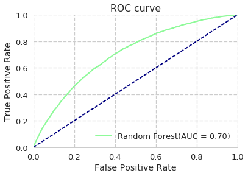

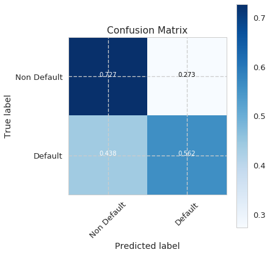

```python
plotAUC(y_test,Predict_rf_proba,'Random Forest')
plt.show()
plt.figure(figsize=(6,6))
plot_confusion_matrix(predicted_rf_test, normalize=True)
plt.show()
```

# 6.3 Extreme Gradient Boosting

First decide values for other purpose hyperparamaters and then use GridSearch to find the best model. This is because it will take too long if I try every combination of hyperparameters using GridSearch. So I gave values to most hyperparamaters using experience first.

```python
param_dist_xgb = {
    'base_score':[0.5],
    'booster':['gbtree'],
    'colsample_bylevel':[1],
       'colsample_bytree':[1],
       'gamma':[0],
       'n_jobs':[1],
       'learning_rate':[0.1,0.15,0.2],
       'max_delta_step':[0], 'max_depth':[4,5,6], 'min_child_weight':[8,10,12],
       'n_estimators':[10,12],
       'random_state':[0],
       'reg_lambda':[1], 'scale_pos_weight':[2.5],
       'subsample':[0.8]
        }

# Fit the random search model
xgb_random = GridSearchCV(estimator=xgb.XGBClassifier(), param_grid=param_dist_xgb, cv = kfold, verbose=1, scoring='roc_auc', n_jobs = -1)
xgb_random.fit(X_train, y_train)

#best model among them
xgb_best=xgb_random.best_estimator_.fit(X_train, y_train)

#predict value
xgb_predicted=xgb_best.predict(X_train)
Predict_xgb_proba = xgb_best.predict_proba(X_train)[:,1]
#show modeling result
print(confusion_matrix(y_train, xgb_predicted))
print(metrics.roc_auc_score(y_train,Predict_xgb_proba))
```

```
Fitting 5 folds for each of 54 candidates, totalling 270 fits
```

```
[Parallel(n_jobs=-1)]: Done  42 tasks      | elapsed:  2.1min
[Parallel(n_jobs=-1)]: Done 192 tasks      | elapsed:  9.7min
[Parallel(n_jobs=-1)]: Done 270 out of 270 | elapsed: 13.9min finished
```

```
[[52328 23671]
 [ 9650 17127]]
0.728396251431
```

```python
xgb_random.best_estimator_
```

```
XGBClassifier(base_score=0.5, booster='gbtree', colsample_bylevel=1,
       colsample_bytree=1, gamma=0, learning_rate=0.2, max_delta_step=0,
       max_depth=6, min_child_weight=12, missing=None, n_estimators=12,
       n_jobs=1, nthread=None, objective='binary:logistic', random_state=0,
       reg_alpha=0, reg_lambda=1, scale_pos_weight=2.5, seed=None,
       silent=True, subsample=0.8)
```

```python
#test
predicted_xgb_test=xgb_best.predict(X_test)
Predict_xgb_proba = xgb_best.predict_proba(X_test)[:,1]
print(confusion_matrix(y_test, predicted_xgb_test))
print(metrics.roc_auc_score(y_test, Predict_xgb_proba))
```

```
[[17314  8032]
 [ 3292  5621]]
0.715432474909
```

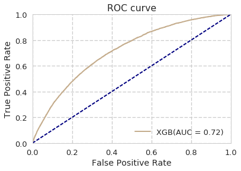

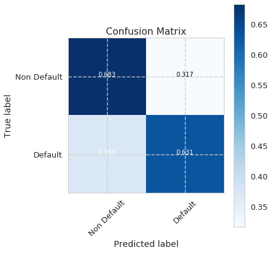

```python
plotAUC(y_test,Predict_xgb_proba,'XGB')
plt.show()
plt.figure(figsize=(6,6))
plot_confusion_matrix(predicted_xgb_test, normalize=True)
plt.show()
```

# 6.5 Feature Importance

Each model's feature importance are slightly different. Here I will choose the feature importance of RF to present.

```python
feature_importances = pd.DataFrame(rf_best.feature_importances_,
                                   index = X_train.columns,
                                    columns=['importance']).sort_values('importance', ascending=False)

print("Features sorted by their importance")
feature_importances
```

```
Features sorted by their importance
```

|  | importance |
| --- | --- |
| int_rate | 0.435092 |
| term | 0.110449 |
| dti | 0.096103 |
| revol_util | 0.055828 |
| annual_inc | 0.047159 |
| total_rev_hi_lim | 0.039921 |
| installment | 0.033620 |
| loan_amnt | 0.032592 |
| earliest_cr_line | 0.018049 |
| revol_bal | 0.016083 |
| zip_code | 0.016031 |
| unkown employment | 0.013469 |
| f | 0.009107 |
| emp_length | 0.008712 |
| Verified | 0.008450 |
| other title | 0.008089 |
| Not Verified | 0.004533 |
| pub_rec | 0.004241 |
| w | 0.003097 |
| CO | 0.002698 |
| credit_card | 0.002602 |
| driver | 0.002514 |
| business owner | 0.001586 |
| NY | 0.001570 |
| RENT | 0.001417 |
| MORTGAGE | 0.001322 |
| debt_consolidation | 0.001112 |
| home_improvement | 0.001110 |
| other purpose | 0.001053 |
| Source Verified | 0.001051 |
| ... | ... |
| ND | 0.000243 |
| LA | 0.000237 |
| MN | 0.000237 |
| officer | 0.000225 |
| NC | 0.000216 |
| KS | 0.000206 |
| AZ | 0.000195 |
| RI | 0.000173 |
| VT | 0.000163 |
| UT | 0.000162 |
| MI | 0.000162 |
| MS | 0.000158 |
| MT | 0.000149 |
| WV | 0.000135 |
| HI | 0.000124 |
| WY | 0.000122 |
| engineer | 0.000114 |
| TN | 0.000098 |
| teacher | 0.000092 |
| AK | 0.000091 |
| SD | 0.000074 |
| JOINT | 0.000055 |
| DC | 0.000042 |
| ME | 0.000034 |
| NM | 0.000025 |
| DE | 0.000022 |
| lawyer | 0.000021 |
| agent | 0.000009 |
| NE | 0.000000 |
| ID | 0.000000 |

99 rows × 1 columns

Let's have a look at relevant feature importance. Here I will choose 20 features. (Usually we choose 10 to 20 according to feature importance)

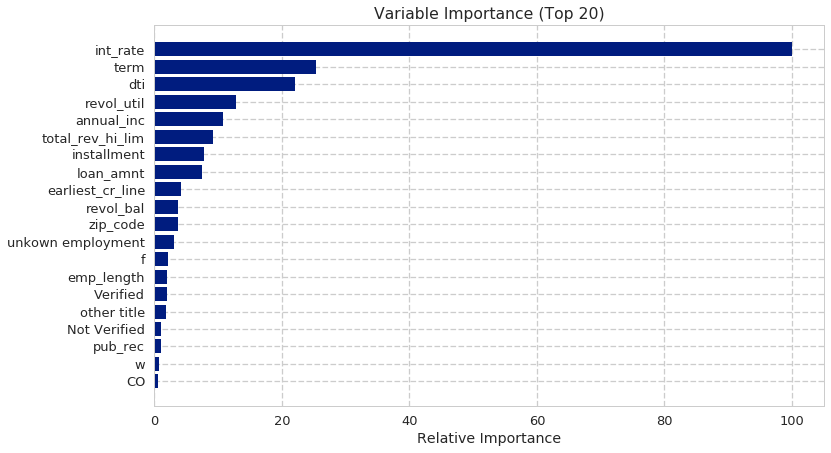

```python
# Normalize features' importance and create a visualization for top 20 features
%matplotlib inline
feature_importance_n = 100.0 * (rf_best.feature_importances_ / rf_best.feature_importances_.max())
sorted_idx = sorted(range(len(feature_importance_n)), key=lambda i: feature_importance_n[i])[-20:]
pos = np.arange(len(sorted_idx)) + .5
plt.figure(figsize=(12, 7))

plt.barh(pos, feature_importance_n[sorted_idx], align='center')
plt.yticks(pos, np.asanyarray(X_train.columns.tolist())[sorted_idx])
plt.xlabel('Relative Importance')
plt.title('Variable Importance (Top 20)')
plt.show()
```

Notice that some of the values belong to the same original column. We should merge them into one variable in the presentation for clients.

# 6.6 Model Comparison

```python
print("RF",classification_report(y_test, predicted_rf_test, target_names=None))
print("LR",classification_report(y_test, predicted_lr_test, target_names=None))
print("XGB",classification_report(y_test, predicted_xgb_test, target_names=None))
print("MLP",classification_report(y_test, predict_mlp_test, target_names=None))
```

[output not shown]

# Model Ensemble

```python
print(metrics.roc_auc_score(y_test, (0.3*Predict_lr_proba+0.4*Predict_xgb_proba+0.3*Predict_rf_proba)))
```

```
0.718573958074
```

[figure not shown]

```python
plotAUC(y_test,Predict_rf_proba, 'Random Forest')
plotAUC(y_test,Predict_lr_proba,'Logistic Regression')
plotAUC(y_test,Predict_xgb_proba,'Extreme Gradient Boosting Tree')
plotAUC(y_test,(+0.4*Predict_xgb_proba+0.3*Predict_rf_proba+0.3*Predict_lr_proba),'Ensemble')
plt.show()
```

# Conclusion

The final auc is 0.72. Not perfect but should be good enough considering the sample size and features we are using.